# digital_methods_knipp_final

Hallie Knipp

2023-05-01

```r
##load libraries
library(tidyverse)
```

```r
library(tidytext)
library(readtext)
library(widyr)
library(dplyr)
library(readxl)
library(ggplot2)
library(SnowballC)
```

```r
library(sotu)

meta <- as.data.frame(sotu_meta)
head(meta)
```

```
##   X         president year years_active       party sotu_type
## 1 1 George Washington 1790    1789-1793 Nonpartisan    speech
## 2 2 George Washington 1790    1789-1793 Nonpartisan    speech
## 3 3 George Washington 1791    1789-1793 Nonpartisan    speech
## 4 4 George Washington 1792    1789-1793 Nonpartisan    speech
## 5 5 George Washington 1793    1793-1797 Nonpartisan    speech
## 6 6 George Washington 1794    1793-1797 Nonpartisan    speech
```

```r
file_paths <- sotu_dir(dir = "sotu_files")
head(file_paths)
```

```
## [1] "sotu_files/george-washington-1790a.txt"
## [2] "sotu_files/george-washington-1790b.txt"
## [3] "sotu_files/george-washington-1791.txt"
## [4] "sotu_files/george-washington-1792.txt"
## [5] "sotu_files/george-washington-1793.txt"
## [6] "sotu_files/george-washington-1794.txt"
```

```r
sotu_texts <- readtext(file_paths)

sotu_whole <-
  sotu_meta %>%
  arrange(president) %>%
  bind_cols(sotu_texts) %>%
  as_tibble()
```

```r
##load birth rates data

USbirthrates <- read_excel("~/USbirthrates.xlsx")
View(USbirthrates)
```

```r
#load workforce data

workforcebysex <- read_excel("~/workforcebysex.xlsx")
View(workforcebysex)
```

```r
#subset datasets / combine datasets

sotu_since1950<- subset(sotu_whole, year %in% c(1950:2020))

workforce_since1950 <- subset(workforcebysex, Year %in% c(1950:2020))

workforce_since1950 <- subset(workforcebysex, MeasureNames=="Women")

birthrate_since1950 <- subset(USbirthrates, year %in% c(1950:2020))


combined <- merge(sotu_since1950, birthrate_since1950, by='year')

combined <- merge(combined, workforce_since1950, 'year'='Year')

combined <- combined %>% select(-c(date, X, years_active, Year))

combined <- combined %>%
  unnest_tokens(word, text)

combined <- combined%>%
        mutate(word_stem = wordStem(word))
```

Twentieth-century feminists have fought consistently for reproductive rights such as access to birth control and abortion. As of 2019, about 65% of women in the United States used some form of contraceptive and, while exact data about the number of women who receive abortions each year is hard to pinpoint, a 2022 Pew Center survey revealed that 62% of American adults believe the practice should be legal “in all or most cases.”[^1] Despite a clear majority of American citizens who agree with such practices, right-wing politicians continually take on reproductive health and anti-choice policies as their platforms of choice. As activist Jenny Brown points out, “in attacking birth control, politicians are taking a stand that is wildly unpopular…”[^2] Brown argues in her 2019 book, Birth Strike, that this can be explained fairly easily; she says that the goal is not to reduce abortions, but to instead increase birth rates. Anxieties surrounding population increase/decrease can be linked to anxieties centered on the availability of a working class, as Brown explains. Using Brown’s argument as a starting point, this project explores the ways in which feminist thought has transformed over the last 75 years and changes in women’s waged work vs. their reproductive choices. Further, it explores presidential state of the union addresses to identify when related topics are discussed and by which administrations. Ideally, this project would be a jumping-off point for further, more detailed research.

Indeed, the birth rate in the United States is in a state of steady decline. As MacroTrends reported, the 1950 birth rate was about 24.3 births per every 1000 people; in 2020, that number had decreased to just under 12 births per 1000 people.[^3] While there are many possible explanations for the decline in birth rates both in the US and internationally, deciphering those reasons lies outside the scope of this project. Rather, I’d like to use the birth rate decline as a backdrop for further research. Utilizing MacroTrends dataset, I have created a graph of the US birth rate between 1950-2020.

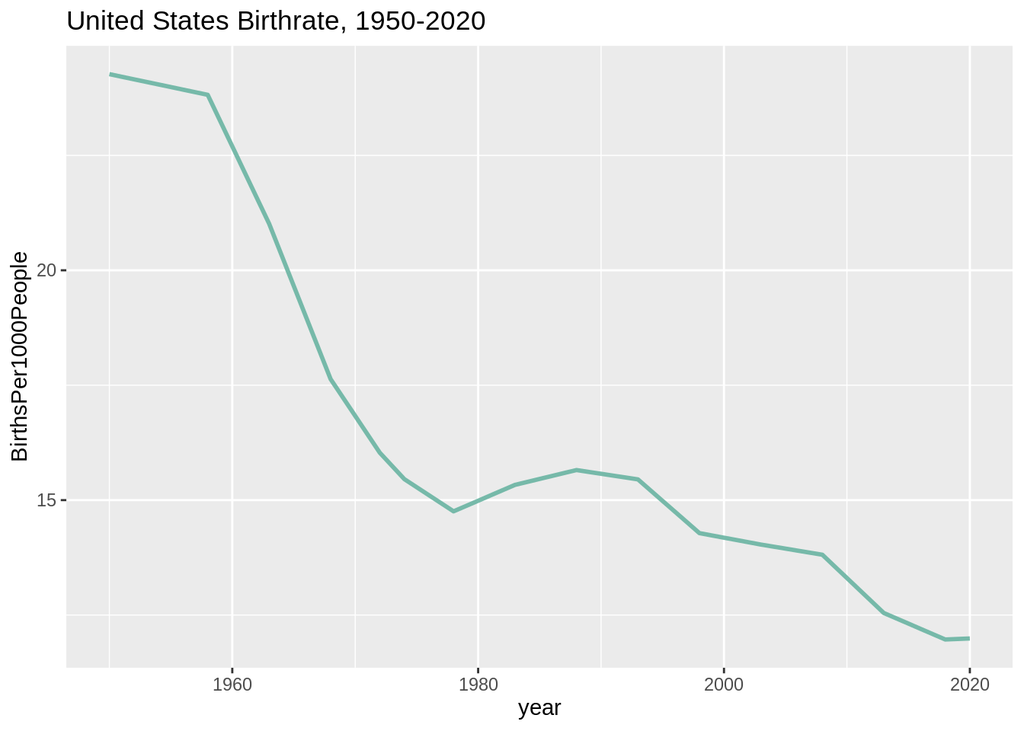

```r
ggplot(combined, aes(x=year, y=BirthsPer1000People)) +
  geom_line( color="#69b3a2", size=1, alpha=0.9, linetype=1) +
  ggtitle("United States Birthrate, 1950-2020")
```

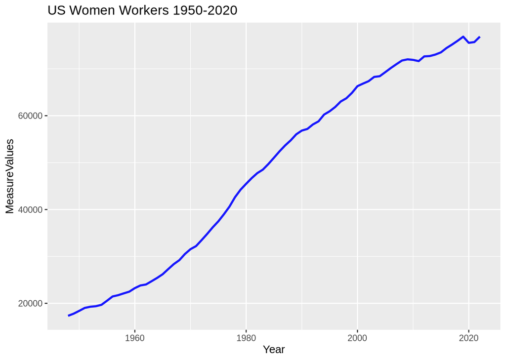

```r
ggplot(workforce_since1950, aes(x=Year, y=MeasureValues)) +
geom_line( color="blue", size=1, alpha=0.9, linetype=1) +
  ggtitle("US Women Workers 1950-2020")
```

Clearly, birth rates have been decreasing while women’s employment has been increasing. Brown outlines in Birth Strike how George H.W. Bush’s views on abortion and reproductive rights changed over time.[^6] She attributes Bush’s early support of birth control in the 60s to his later support of the Global Gag Rule in 1984 (which banned foreign aid “to any family planning agency that so much as mentions abortions”[^7]) as choices which align with nationwide birth rates. She argues that during the baby boom elite politicians worried about overpopulation and thus, the birth control pill was made widely available; by the 1980s, the birth rate drastically decreased, and reproductive planning options were pulled back. Instead of performing a close analysis of any given politician’s views, though, I performed a distant analysis of state of the union addresses between 1950-2020 in order to see when the word “women” was used over the 70-year period; this could be done with any keyword.

In order to do this, I subsetted the State of the Union address data to only show the years I was interested in, tokenized the text, and then searched the text for the word “women.” I then graphed the use of “women” between 1950-2020.

```r
#subset SOTU words

filter_women <-
  combined %>%
  filter(word %in% c("women")) %>%
  count(year, word) %>%
  group_by(year) %>%
 mutate(n_tot = sum(n))
```

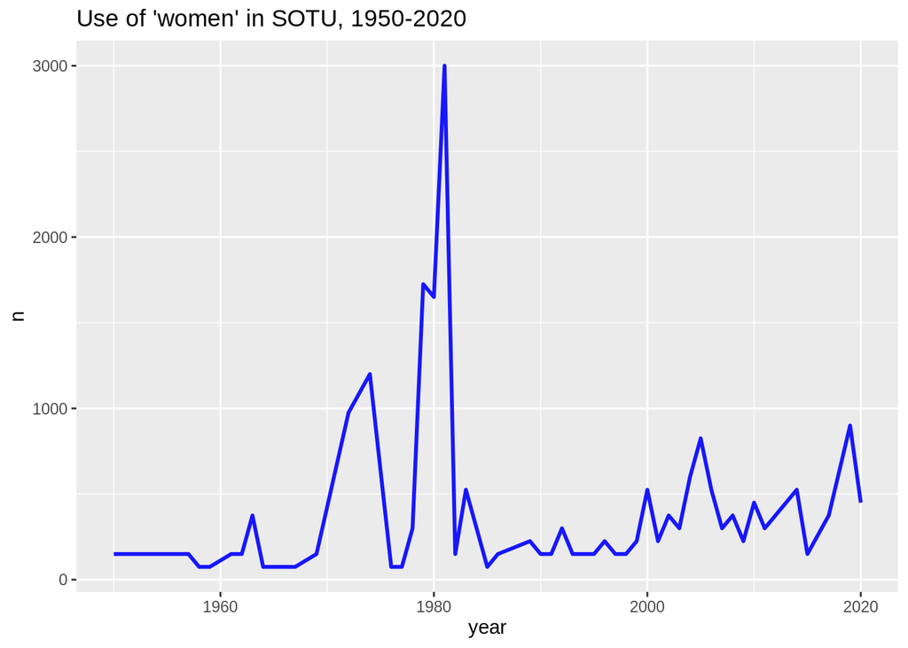

```r
ggplot(filter_women, aes(x=year, y=n)) +
geom_line( color="blue", size=1, alpha=0.9, linetype=1) +
  ggtitle("Use of 'women' in SOTU, 1950-2020")
```

In the early twentieth century, labor activists fought for a so-called family wage, which in layman’s terms meant that the head of household would work for a wage which would also support his (and it was always “his”) family. While this policy was obliquely sexist, it set a precedent that employers had a responsibility to not just the worker in his direct employ but also to the labor of the employee’s household.[^8] Brown writes, “While the family wage never covered all of the working class…the family wage did make it possible to support both a breadwinner and a homemaker, along with children, on one paycheck.” [^9] The idea of a family wage, though it implied a necessary reimbursement of household labor in order to uphold the breadwinner, also hurt women’s wages when they were involved in the formal workforce because it was assumed that women’s waged income would be supplemental to her husband’s income. By the 1980s, “working mothers had become a pillar of the economy,” yet the legacy of the family wage assured their wages stayed low. [^10] Brown writes, “The family wage…was an excuse to pay women less…Over time, whole occupations switched from ‘male’ to ‘female’ to take advantage of women’s lower pay: telephone operators, bank clerks, teachers. As a result, equal pay has been regarded as a working-class priority, at least by the most forward-thinking portions of the labor movement.”^ [Brown, 2020] By the 1980s, the family wage was largely a thing of the past; Swinth goes as far to say that in the 1980s “the family wage system, with its norm of male breadwinners and female homemakers, definitively imploded.” [^11] Yet, the Reagan administration fought hard against and ended many existing social programs which sought to answer the problems faced by two-earner households (not to mention those faced by working single mothers).

This history is crucial to understanding the change in the United States working class, as the fading out of the family wage directly affected both the number of married women involved in wage work and the number of children that married heterosexual couples chose to have. The decreasing birth rate is not a phenomena unique to the United States; in fact, the United Nations predicts that worldwide, only nations on the African continent will grow in non-immigrant population by 2100 [^12] However, unlike several European countries which met this decreasing birth rate with mandates “that employers provide, or pay into a government fund to provide, a substantial ‘social wage’ to replace the family wage, including long paid maternal or parental leave, sick leave, and vacations, guaranteed child care and health care, and free schooling through college,” [^13] the US has no such “social wage” program.

Further research utilizing an expanded corpus would be necessary to make broad conclusions, but it is clear that falling birth rates and rising numbers of women in the workforce share some kind of connection; further, a larger corpus of political rhetoric (not just the SOTU address data) should be analyzed in a similar fashion in order to see if the use of “women” and related keywords spikes at similar rates as the SOTU data. This project does not seek to make broad generalizations based on a limited corpus, but rather to serve as a starting point for further research. That being said, there are clearly interesting conclusions to be drawn from this limited corpus.

[^1]: Daniels and Abma 2020, Diamant and Mohamed 2023
[^2]: Brown 2019, 5
[^3]: “U.S. Birth Rate 1950-2023 | MacroTrends.”
[^4]: Federici 2021, 3.
[^5]: “Civilian Labor Force by Sex”
[^6]: Brown 2019, 75
[^7]: Brown 2021, 75
[^8]: Brown, 2020
[^9]: Brown, 2020
[^10]: Swinth 2018, 311
[^11]: Swinth 2018, 311
[^12]: United Nations, Department of Economic and Social Affairs, Population Division.
[^13]: Brown 2020